# Session Six - Transforming Manipulating Data Objects

By Hellen Gakuruh

January 18, 2017

## Session Goal

The main goal of this session is to facilitate you to make necessary pre-analysis activities.

## What we shall cover

By the end of this session you should:

- Be able to index values/elements any R data object
- Know how to use binary operators to make comparison and check conditions
- Understand vectorisation in R
- Have the skills to extract and/or replace parts of any data object in R

## Prerequisite

To appreciate this session, you must be conversant with:

- Making function calls
- Difference between errors and warnings
- R’s data types and objects
- Installing and loading packages
- Importing data into R

## Indexing different data objects in R

An index is a position marker or identifier of values/elements in an object. There are two ways to specify an index, with an numerical or a character (for named values/elements). Logical value TRUE, FALSE and NA can also be used to index elements of a vector, but they eventualy become integers (1 for TRUE and 0 for FALSE).

Values in a vector are indexed by the dimensions of the vector, hence, a one dimensional vector like a basic atomic vector or a list would have one index while a two dimensional vector such as a matrix or a data frame, would have two indices. Higher dimensional vectors like arrays, have indices the same length as its dimension, for example, a three dimensional array would have three indices.

### Indexing one dimensional objects

One dimensional vectors include basic vectors and lists. Values or elements are specified with one index.

#### One dimension (1d) Atomic/Homogenous vectors

```r
set.seed(6839)
x <- sample(1:100, 10)
x
```

```
##  [1] 35 24 78 59 82  9 52 75 80 94
```

Vector x has 10 values, the position of each of these values gives its index as an integer.

| Value | Index |
| --- | --- |
| 35 | 1 |
| 24 | 2 |
| 78 | 3 |
| 59 | 4 |
| 82 | 5 |
| 9 | 6 |
| 52 | 7 |
| 75 | 8 |
| 80 | 9 |
| 94 | 10 |

If this vector were named, then values can be specified with their names

```r
# Character index
names(x) <- letters[1:10]
x
```

```
##  a  b  c  d  e  f  g  h  i  j
## 35 24 78 59 82  9 52 75 80 94
```

| Value | Index |
| --- | --- |
| 35 | “a” |
| 24 | “b” |
| 78 | “c” |
| 59 | “d” |
| 82 | “e” |
| 9 | “f” |
| 52 | “g” |
| 75 | “h” |
| 80 | “i” |
| 94 | “j” |

#### One dimension (1d) Generic/Heterogeneous vectors

Lists are one dimensional objects whose contents can have different types of objects (hence heterogenous). Like basic atomic vectors, they are indexed with one value.

```r
library(reshape2)
aList <- list(data = head(tips), metaData = c("This dataset is from Reshape2 package"))
aList
```

```
## $data
##   total_bill  tip    sex smoker day   time size
## 1      16.99 1.01 Female     No Sun Dinner    2
## 2      10.34 1.66   Male     No Sun Dinner    3
## 3      21.01 3.50   Male     No Sun Dinner    3
## 4      23.68 3.31   Male     No Sun Dinner    2
## 5      24.59 3.61 Female     No Sun Dinner    4
## 6      25.29 4.71   Male     No Sun Dinner    4
##
## $metaData
## [1] "This dataset is from Reshape2 package"
```

| Objects in the list | Integer indexing | Character indexing |
| --- | --- | --- |
| First element | 1 | “data” |
| Second element | 2 | “metaData” |

Elements in a list can further be indexed per their dimension. In this case there are two elements; the first is a data frame with two dimensions and the second is a one dimesional character vector both of which can be indexed by their dimensions.

#### Indexing One Dimension Character vectors

Charater or string vectors are slightly different when it comes to indexing. Indices are given per character which include spaces and punctuation marks. Words can be indexed with a range of indices from its beginning to its end. This range can easily be determined by a package called “strigi”.

```r
library(stringi)
char <- "This is session six"
stri_locate_all_words(char)
## [[1]]
##      start end
## [1,]     1   4
## [2,]     6   7
## [3,]     9  15
## [4,]    17  19
```

### Indexing two dimensional vectors

There are two types of two dimensional objects commonly used in R, these are matrices which are atomic or homogeneous vectors and data frames which are generic or heterogeneous objects.

#### Two dimensional (2d) Atomic/Homogenous vectors

Matrices are two dimensional objects that contain one data type (homogeneous). Since they have two dimensions, values are specified with two indices; row and column.

```r
set.seed(1038)
mat <- matrix(round(rnorm(12, 50, 5), 1), nrow = 4)
dimnames(mat) <- list(letters[1:4], LETTERS[1:3])
mat
```

```
##      A    B    C
## a 45.7 58.6 47.7
## b 52.9 47.2 45.0
## c 50.5 52.7 55.2
## d 42.2 41.5 47.6
```

“Mat” has twelve values. Each value can be specified by its row and column position.

| Value | Integer indices | Character indicies |
| --- | --- | --- |
| 45.7 | 1, 1 | “a, A” |
| 52.9 | 2, 1 | “b, A” |
| 50.5 | 3, 1 | “c, A” |
| 42.2 | 4, 1 | “d, A” |
| 58.6 | 1, 2 | “a, B” |
| 47.2 | 2, 2 | “b, B” |
| 52.7 | 3, 2 | “c, B” |
| 41.5 | 4, 2 | “d, B” |
| 47.7 | 1, 3 | “a, C” |
| 45.0 | 2, 3 | “b, C” |
| 55.2 | 3, 3 | “c, C” |
| 47.6 | 4, 3 | “d, C” |

An index 1,1 means first row, first column and “a, A” means row name “a” and column name “A”. A complete row can be indexed with an integer or name of the row followed by a blank column index.

| Row | Integer indices | Character indices |
| --- | --- | --- |
| First | 1, | “a,” |
| Second | 2, | “b,” |
| Third | 3, | “c,” |
| Fourth | 4, | “d,” |

To index a column.

[output not shown]

### Atomic/Homogenous vectors with more than 2 dimensions (>2d)

Arrays are atomic vectors with one or more dimensions, matrices is a special case of an array. For one dimensional array, indexing is like a basic vector while two dimensional arrays would be indexed like a matrix. In the case of arrays with more than two dimensions, values are indexed by the number of dimensions, so for a three dimensional array, values are specified with three indices.

```r
ucbArray
## , , Dept = A
##
##           Gender
## Admit      Male Female
##   Admitted  512     89
##   Rejected  313     19
##
## , , Dept = B
##
##           Gender
## Admit      Male Female
##   Admitted  353     17
##   Rejected  207      8

# Dimensions
dim(ucbArray)
```

```
## [1] 2 2 2
```

```r
length(dim(ucbArray))
```

```
## [1] 3
```

```r
# Number of values in the array
length(as.vector(ucbArray))
```

```
## [1] 8
```

“ucbArray” is an array with three dimensions and 8 values. The first index is for row, the second is for columns and the third is for subsetction or layer like departments in this case.

[output not shown]

An index of 2,2,1 means a value in the second row, second column and first layer (department).

#### Two dimensional (2d) Generic/Heterogeneous vectors

Data frames are generic or heterogeneous vectors. They are the most widely used data objects in R. Being two dimensions, data frame values are indexed as matrices; by their row and column position.

```r
irisSub
```

```
##   Sepal.Length Petal.Length Species
## 1          5.1          1.4  setosa
## 2          4.9          1.4  setosa
## 3          4.7          1.3  setosa
## 4          4.6          1.5  setosa
## 5          5.0          1.4  setosa
```

```r
# Dimension
dim(irisSub)
```

```
## [1] 5 3
```

```r
# Number of dimensions
length(dim(iris))
```

```
## [1] 2
```

```r
# Total number of values
length(irisSub) * nrow(irisSub)
```

```
## [1] 15
```

“irisSub” is a data frame with two dimensions (5 row and 3 columns) and 15 values. Each of these values can be indexed by their row and column position.

| Value | Integer indices | Character indices |
| --- | --- | --- |
| 5.1 | 1, 1 | 1, “Sepal.Length” |
| 1.4 | 1, 2 | 1, “Petal.Lenght” |
| setosa | 1, 3 | 1, “Species” |
| 4.9 | 2, 1 | 2, “Sepal.Length” |
| 1.4 | 2, 2 | 2, “Petal.Length” |
| setosa | 2, 3 | 2, “Species” |
| 4.7 | 3, 1 | 3, “Sepal.Length” |
| 1.3 | 3, 2 | 3, “Petal.Length” |
| setosa | 3, 3 | 3, “Species” |
| 4.6 | 4, 1 | 4, “Sepal.Length” |
| 1.5 | 4, 2 | 4, “Petal.Length” |
| setosa | 4, 3 | 4, “Species” |
| 5.0 | 5, 1 | 5, “Sepal.Length” |
| 1.4 | 5, 2 | 5, “Petal.Length” |
| setosa | 5, 3 | 5, “Species” |

Notice we can mix both integers and character indices, in this case we had to mix them as rows are not named.

There are two important issues that needs to be discussed before venturing into subsetting and data manipulation, these are binary operators and conditional functions useful for subsetting.

## Binary and vectorisation Operators

### Comparison Operators

Comparison operators also known as relational operators are functions for comparing values of atomic vectors (they have only one data type). R has six comparison operators, these are:

| Operator | Usage |
| --- | --- |
| == | Equal |
| != | Not Equal |
| < | Less than |
| <= | Less than or equal to |
| > | Greater than |
| >= | Greater than or equal to |

These operators output/produce logical values TRUE, FALSE or NA.

#### Equality

To test equality, we will begin with length-one atomic vectors.

```r
# Comparing integers
2L == 3L
```

```
## [1] FALSE
```

```r
# Comparing doubles
3.56 == 3.6
```

```
## [1] FALSE
```

```r
round(3.56, 1) == 3.6
```

```
## [1] TRUE
```

```r
# Comparing characters (words)
"Hellen" == "Helen"
```

```
## [1] FALSE
```

```r
# Comparing Logical values
TRUE == FALSE
```

```
## [1] FALSE
```

**Vectorized Comparison**

Binary operators can also be used with vectors of length greater than one. In this case comparison is carried out element by element producing a logical vector the same length as the two vectors being compared. This type of comparison; elementwise, is referred to as **vectorized comparison**. Therefore vectorization allows comparison to be done between elements of two (binary) vectors.

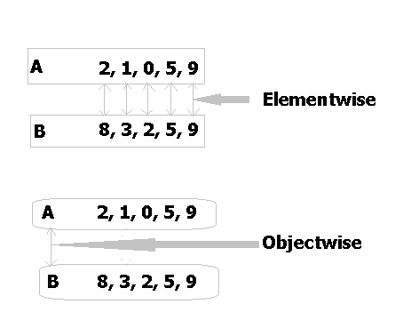

Do take note, if two vectors are of different lengths, the shorter vector is recycled until it reaches the same length as the longer vector before comparison is carried out, this will result in an output and a warning.

```r
# elementwise comparison
a <- c(2, 1, 0, 5, 9)
b <- c(8, 3, 2, 5, 9)
a == b
```

```
## [1] FALSE FALSE FALSE  TRUE  TRUE
```

```r
# Comparison with a shorter vector
c <- c(2, 2)
a == c
```

```
## Warning in a == c: longer object length is not a multiple of shorter object
## length
## [1]  TRUE FALSE FALSE FALSE FALSE
```

```r
b == c
```

[output not shown]

To check equality between two vectors as an objects rather that its elements only, function “identical” and “all.equal” are more appropriate. Objectwise comparison also involves checking type and attributes of the object for equality.

```r
a == b
```

```
## [1] FALSE FALSE FALSE  TRUE  TRUE
```

```r
identical(a, b)
```

```
## [1] FALSE
```

```r
all.equal(a, b)
```

```
## [1] "Mean relative difference: 3.333333"
```

There are subtle difference between “identical” and “all.equal”. All.equal checks for “nearness” but identical checks for complete equality.

```r
e <- c(round(1.2938), round(3.2903), round(6.3958))
f <- c(1L, 3L,  6L)
e == f
```

```
## [1] TRUE TRUE TRUE
```

```r
class(e); class(f)
```

```
## [1] "numeric"
## [1] "integer"
```

```r
typeof(e); typeof(f)
```

```
## [1] "double"
## [1] "integer"
```

```r
identical(e, f)
```

```
## [1] FALSE
```

```r
all.equal(e, f)
```

```
## [1] TRUE
```

These two functions (identical and all.equal) will become useful when discussing control structures.

#### Non - Equality

Non-equality between two (binary) objects is done using negation, that is “!=”.

```r
# Length-one vectors
2 != 3
```

```
## [1] TRUE
```

```r
2L != 3L
```

```
## [1] TRUE
```

```r
"Hellen" != "Helen"
```

```
## [1] TRUE
```

```r
TRUE != FALSE
```

```
## [1] TRUE
```

```r
# Vectors with length > 1
a; b
```

```
## [1] 2 1 0 5 9
## [1] 8 3 2 5 9
```

```r
a != b
```

```
## [1]  TRUE  TRUE  TRUE FALSE FALSE
```

```r
# They look the same but are not the same
e; f
```

```
## [1] 1 3 6
## [1] 1 3 6
```

```r
e != f
```

```
## [1] FALSE FALSE FALSE
```

#### Greater than operator

This operator typically asks if value(s) on the left hand side is(are) greater than the value(s) on the right hand side.

```r
2 > 3
```

```
## [1] FALSE
```

```r
2L > 3L
```

```
## [1] FALSE
```

```r
# Comparison for words is by each character
"Hellen" > "Helen"
```

```
## [1] TRUE
```

```r
# Logical values are interally stored as 1 for TRUE and 0 for FALSE
TRUE > FALSE
```

```
## [1] TRUE
```

```r
# Element comprison for vectors > 1
a; b
```

```
## [1] 2 1 0 5 9
## [1] 8 3 2 5 9
```

```r
a > b
```

```
## [1] FALSE FALSE FALSE FALSE FALSE
```

```r
# Comparison for double and integer vectors (taking account of decimal point)
e; f
```

```
## [1] 1 3 6
## [1] 1 3 6
```

```r
e > f
```

```
## [1] FALSE FALSE FALSE
```

#### Greater than or equal operator

This operator checks if the left value is greater than or equal to the value on the right.

```r
2 >= 3
```

```
## [1] FALSE
```

```r
2L >= 3
```

```
## [1] FALSE
```

```r
"Hellen" >= "Helen"
```

```
## [1] TRUE
```

```r
TRUE >= FALSE
```

```
## [1] TRUE
```

```r
a; b
```

```
## [1] 2 1 0 5 9
## [1] 8 3 2 5 9
```

```r
a >= b
```

```
## [1] FALSE FALSE FALSE  TRUE  TRUE
```

```r
e; f
```

```
## [1] 1 3 6
## [1] 1 3 6
```

```r
e >= f
```

```
## [1] TRUE TRUE TRUE
```

#### Less than operator

This operator compares two values to see if the first is smaller than the second value.

```r
2 < 3
```

```
## [1] TRUE
```

```r
2L < 3
```

```
## [1] TRUE
```

```r
"Hellen" < "Helen"
```

```
## [1] FALSE
```

```r
TRUE < FALSE
```

```
## [1] FALSE
```

```r
# Vectorized
a; b
```

```
## [1] 2 1 0 5 9
## [1] 8 3 2 5 9
```

```r
a < b
```

```
## [1]  TRUE  TRUE  TRUE FALSE FALSE
```

```r
e; f
```

```
## [1] 1 3 6
## [1] 1 3 6
```

```r
e < f
```

```
## [1] FALSE FALSE FALSE
```

#### Less than or equal to operator

Finally this operator compares the two values to see if the first is equal or less than the second value.

```r
2 <= 3
```

```
## [1] TRUE
```

```r
2L <= 3
```

```
## [1] TRUE
```

```r
"Hellen" <= "Helen"
```

```
## [1] FALSE
```

```r
TRUE <= FALSE
```

```
## [1] FALSE
```

```r
# Vectorized
a; b
```

```
## [1] 2 1 0 5 9
## [1] 8 3 2 5 9
```

```r
a <= b
```

```
## [1] TRUE TRUE TRUE TRUE TRUE
```

```r
e; f
```

```
## [1] 1 3 6
## [1] 1 3 6
```

```r
e <= f
```

```
## [1] TRUE TRUE TRUE
```